# Workshop 2 - Machine Learning-Based Approaches for Text Mining

Wei-Hung Weng

July 5, 2017

## Objectives

Participants may leave this workshop with skills to:

- Perform the **topic modeling** algorithm on the textual data in R
- Understand the concept of **word embedding** representation and apply it in R
- Learn a **hidden representation of deep neural network** from textual data in R

## Instructions

**Before beginning**, please test to see if the Rmd file will compile on your system by clicking the “Knit HTML button” in R studio above.

## Machine learning approaches for text mining

Machine learning is a powerful tool for text mining, especially finding the hidden representation, which is impossible if we just use regular expressions or simple NLP techniques.

In this workshop, we will use machine learning algorithms to perform topic modeling, word embedding and extracting a hidden representation of the text using deep autoencoder. We will use the iDASH dataset and R language for the workshop. First, we will import the iDASH data and labels (please see the previous workshop for the introduction of the dataset).

```r
# read the iDASH data
idash <- read.table("idash.txt", sep = "\t", header = FALSE, comment.char="", stringsAsFactors = FALSE)
# store texts to "data"
data <- idash$V1
# store labels to "label"
label <- as.factor(idash$V2)
```

## Learning language model to find the theme of the document - topic modeling

Topic modeling is an unsupervised learning technique to summarize and organize a large amount of textual information. Topic modeling algorithms can help us identify the words/terms which can be grouped into the same cluster (refer to “topic”) from a collection of documents, discover hidden topics among the documents, annotate/label the documents by the identified groups (topics), and therefore understand, summarize, separate, and organize bunch of textual data. In other words, topic modeling may help us find out a hidden thematic representation of the document.

We choose the Latent Dirichlet allocation (LDA) algorithm, which is a common and popular mathematical topic modeling method developed by Prof. David Blei, for topic modeling. LDA can estimate both of the followings at the same time: (1) each word in the document collection is attributable to one of the document’s topics, and (2) each document (a set of words) is viewed as a mixture of topics that are present in the document collection. For example:

- Document 1: a cardiology admission note, 80% cardiology, 15% nephrology, 4% pulmonology, 1% neurology
- Document 2: a kidney biopsy report, 50% nephrology, 30% rheumatology, 15% infectious disease, 5% neurology
- Document 3: a chest CT report, 50% pulmonology, 40% cardiology, 5% oncology, 5% infectious disease
- …

Here each clinical document has multiple topics with different proportion. In this example, medical specialties can be regarded as natural topics of the document collection. If we dive into keywords of each topic, you may see something like:

- Cardiology: ventricle, ekg, atrial, catheterization, cabg, edema, …
- Nephrology: hemodialysis, renal, edema, nephritis, sonography, dyspnea, …
- Pulmonology: dyspnea, lung, bronchitis, adenocarcinoma, egfr, edema, …
- Infectious disease: hiv, hepatitis, viral, fever, leukocytosis, …
- …

To be noticed, words can be shared across topics.

We use the `LDA` function in `topicmodels` package to generate an LDA topic model. The `LDA` function takes a document-term matrix as an input, which can be generated using `tm` package that we introduced at the end of the previous workshop.

```r
# as the previous workshop, we use tm to build document-term matrix
library(tm)
library(SnowballC)
corpus <- Corpus(VectorSource(data))
corpus <- tm_map(corpus, tolower)
corpus <- tm_map(corpus, PlainTextDocument)
corpus <- tm_map(corpus, removePunctuation)
corpus <- tm_map(corpus, removeNumbers)
corpus <- tm_map(corpus, stripWhitespace)
corpus <- tm_map(corpus, removeWords, c(stopwords("english")))
corpus <- tm_map(corpus, stemDocument)

dtm <- DocumentTermMatrix(corpus)
# add the document name (just simply use the number)
rownames(dtm) <- 1:nrow(idash)
```

In the LDA algorithm, we need to assign the number of possible natural topics (`k`) to `LDA` function. For example, we set `k = 6` to create a six-topic LDA model. You may use `topics` function to get the topic of each document, and apply `terms` function to see keywords of each topic (here we show top 30 keywords).

```r
library(topicmodels)
# build LDA model
lda_model <- LDA(dtm, k = 6, control = list(seed = 777))
# show assigned clusters of the first 50 documents
lda_topics <- topics(lda_model, 1)
lda_topics[1:50]
```

```
##  1  2  3  4  5  6  7  8  9 10 11 12 13 14 15 16 17 18 19 20 21 22 23 24 25
##  6  2  5  5  5  5  6  6  6  6  6  6  6  6  6  4  5  5  6  6  6  6  6  6  6
## 26 27 28 29 30 31 32 33 34 35 36 37 38 39 40 41 42 43 44 45 46 47 48 49 50
##  6  5  6  6  6  6  6  6  6  6  6  6  6  6  6  6  6  6  6  5  5  5  2  5  5
```

```r
# get keywords of each LDA topic
lda_keywords <- data.frame(terms(lda_model, 30), stringsAsFactors = FALSE)
lda_keywords
```

```
##       Topic.1   Topic.2     Topic.3    Topic.4  Topic.5     Topic.6
## 1     patient   patient     patient       left  patient        left
## 2      report   histori    procedur      right  histori      arteri
## 3        time     medic      normal   unremark   normal       right
## 4     histori       day       colon     normal    heart    coronari
## 5       medic      will       right       exam     left      cathet
## 6        test      past       place     reveal     pain     patient
## 7        year    diseas         use    bilater    chest     pressur
## 8        also     daili        left       time   diseas         use
## 9      memori      also      biopsi       note     rate   pulmonari
## 10     averag      time        well    present   arteri    procedur
## 11      state      pain       scope      brain coronari      normal
## 12    depress     blood       tumor        mri    medic ventricular
## 13   function  discharg       polyp    headach     show      branch
## 14       note      deni       remov        day     test      french
```

[output cut: 16 more lines]

As you can see in `lda_topics`, most of first 50 documents are assigned to topic 5 or 6. From `lda_keywords`, topic 3 seems like gastroenterology, topic 4 might be neurology, topic 1 is psychology, topic 5 and 6 are cardiology, topic 2 is unclear.

```r
library(tidytext)
beta <- tidy(lda_model, matrix = "beta")
beta[1:20, ]
```

```
## # A tibble: 20 × 3
##    topic    term          beta
##    <int>   <chr>         <dbl>
## 1      1     aaa 1.272744e-276
## 2      2     aaa  3.519668e-05
## 3      3     aaa 3.330001e-278
## 4      4     aaa 4.184585e-274
## 5      5     aaa 1.928054e-256
## 6      6     aaa 2.392378e-279
## 7      1    aaaa  5.041184e-05
## 8      2    aaaa 8.504099e-295
## 9      3    aaaa 2.317572e-298
## 10     4    aaaa 1.287829e-283
## 11     5    aaaa 2.595080e-292
## 12     6    aaaa 1.314820e-298
## 13     1   aampo  1.008237e-04
## 14     2   aampo  2.579104e-40
## 15     3   aampo 9.917867e-284
## 16     4   aampo 6.723912e-280
## 17     5   aampo 1.485989e-278
## 18     6   aampo 1.009843e-283
## 19     1 abandon  1.512347e-04
## 20     2 abandon  5.413660e-10
```

```r
gamma <- tidy(lda_model, matrix = "gamma")
gamma[c(1:5, (431+1):(431+5), (431*2+1):(431*2+5), (431*3+1):(431*3+5)),]
```

```
## # A tibble: 20 × 3
##    document topic        gamma
##       <chr> <int>        <dbl>
## 1         1     1 1.813062e-04
## 2         2     1 7.982333e-05
## 3         3     1 1.299059e-04
## 4         4     1 1.140099e-04
## 5         5     1 1.614132e-04
## 6         1     2 1.813062e-04
## 7         2     2 9.996009e-01
## 8         3     2 1.299059e-04
## 9         4     2 1.140099e-04
## 10        5     2 1.614132e-04
## 11        1     3 1.813062e-04
## 12        2     3 7.982333e-05
## 13        3     3 1.299059e-04
## 14        4     3 1.140099e-04
## 15        5     3 1.614132e-04
## 16        1     4 1.813062e-04
## 17        2     4 7.982333e-05
## 18        3     4 1.299059e-04
## 19        4     4 1.140099e-04
## 20        5     4 1.614132e-04
```

LDA-derived topics/clusters can be used as natural labels for machine classification (supervised learning). We run a simple decision tree as an example. The accuracy is 0.7874, which is not that bad.

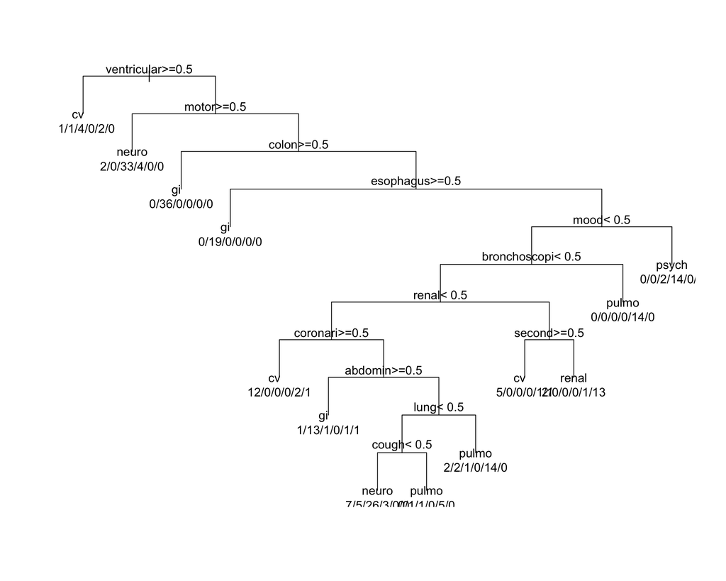

```r
d <- data.frame(as.matrix(dtm))
d$label <- label

# build a decision tree
library(caret)
library(rpart)
# split the dataset based on the label (70% training, 30% testing)
set.seed(123)
inTraining <- createDataPartition(d$label, p=0.7, list=F)
training <- d[ inTraining, ]
testing <- d[-inTraining, ]

# build the decision tree
model <- rpart(label~., data=training)
#summary(model)
# plot the decision tree
plot(model, uniform=TRUE)
text(model, use.n=TRUE)
```

```r
tst <- testing
tst$label = NULL
# evaluate the performance
pred <- predict(model, tst, type="class")
confusionMatrix(testing$label, pred)
```

```
## Confusion Matrix and Statistics
##
##           Reference
## Prediction cv gi neuro psych pulmo renal
##      cv    30  1     2     0     0     1
##      gi     1 25     5     0     0     2
##      neuro  3  1    25     0     0     0
##      psych  0  0     3     6     0     0
##      pulmo  4  2     1     0     9     0
##      renal  0  0     0     0     1     5
##
## Overall Statistics
##
##                Accuracy : 0.7874
##                  95% CI : (0.706, 0.855)
##     No Information Rate : 0.2992
##     P-Value [Acc > NIR] : < 2.2e-16
##
##                   Kappa : 0.7273
##  Mcnemar's Test P-Value : NA
##
## Statistics by Class:
##
##                      Class: cv Class: gi Class: neuro Class: psych
## Sensitivity             0.7895    0.8621       0.6944      1.00000
## Specificity             0.9551    0.9184       0.9560      0.97521
## Pos Pred Value          0.8824    0.7576       0.8621      0.66667
## Neg Pred Value          0.9140    0.9574       0.8878      1.00000
## Prevalence              0.2992    0.2283       0.2835      0.04724
## Detection Rate          0.2362    0.1969       0.1969      0.04724
## Detection Prevalence    0.2677    0.2598       0.2283      0.07087
## Balanced Accuracy       0.8723    0.8902       0.8252      0.98760
##                      Class: pulmo Class: renal
## Sensitivity               0.90000      0.62500
## Specificity               0.94017      0.99160
## Pos Pred Value            0.56250      0.83333
## Neg Pred Value            0.99099      0.97521
## Prevalence                0.07874      0.06299
## Detection Rate            0.07087      0.03937
## Detection Prevalence      0.12598      0.04724
## Balanced Accuracy         0.92009      0.80830
```

### Exercise

Again, we use the [**PhysioNet Deidentified Medical Text**](https://physionet.org/works/DeidentifiedMedicalText/) as an example for the exercise.

```r
x <- readChar("id.txt", file.info("id.txt")$size)
x <- gsub("\n\n\\|\\|\\|\\|END_OF_RECORD\n\nSTART_OF_RECORD=[0-9]+\\|\\|\\|\\|[0-9]+\\|\\|\\|\\|\n", " [split] ", x)
x <- gsub("\n\n\\|\\|\\|\\|END_OF_RECORD\n\n", "", x)
x <- strsplit(x, " \\[split\\] ")
x <- x[[1]]
```

Try to use LDA to find the topic words (assuming that there are 5 topics), and find the topic of each document.

### Answer

```r
library(tm)
library(SnowballC)
library(topicmodels)

corpus <- Corpus(VectorSource(x))
corpus <- tm_map(corpus, tolower)
corpus <- tm_map(corpus, PlainTextDocument)
corpus <- tm_map(corpus, removePunctuation)
corpus <- tm_map(corpus, removeNumbers)
corpus <- tm_map(corpus, stripWhitespace)
corpus <- tm_map(corpus, removeWords, c(stopwords("english")))
corpus <- tm_map(corpus, stemDocument)
dtm <- DocumentTermMatrix(corpus)

lda_model <- LDA(dtm, k = 5, control = list(seed = 777))

lda_keywords <- data.frame(terms(lda_model, 10), stringsAsFactors = FALSE)
lda_keywords
```

```
##    Topic.1 Topic.2 Topic.3 Topic.4 Topic.5
## 1     will   neuro   given   neuro  remain
## 2     resp    time    vent  remain    resp
## 3  continu    wean     gtt  follow     sat
## 4   remain   sedat    resp   today   stabl
## 5     cont    cont command   thick    urin
## 6      med   chang    cont increas    note
## 7     note  secret   sound     abg continu
## 8    clear     sat    cath   place   today
## 9    stool increas    wean   lasix    cont
## 10    plan    vent  famili     sat     gtt
```

```r
# use the result of LDA for supervised learning
x_df <- as.data.frame(x)
x_df$label <- topics(lda_model, 1)
```

## Learning language model for word vector representation - word embedding

Word embedding is a natural language modeling method for word vector representation. Simply to say, it is a technique to represent words as vectors. Instead of very sparse one-hot representation or frequency count representation (bag-of-words), word embedding approach may encode each word of the large corpus into a dense vector, with semantics and linguistic regularities that bag-of-words can’t achieve. One of the most famous examples of word embedding might be the following operation:

$$vector('paris') - vector('france') + vector('germany') = vector('berlin')$$

Please check [wikipedia introduction](https://en.wikipedia.org/wiki/Word_embedding) for more background knowledge of word embedding. The most popular word embedding algorithms, [word2vec](https://en.wikipedia.org/wiki/Word2vec) and [GloVe (Global Vectors for Word Representation)](https://nlp.stanford.edu/projects/glove/), were developed by Mikolov at Google and Pennington at Stanford, respectively.

In Python, you can use `gensim` or `tensorflow` for word2vec implementation. Now, we’d like to introduce `text2vec` package, which is a R package that using C++ as the backend for GloVe implementation. `text2vec` will help you process raw data through the following steps:

1. Create a vocabulary set that we want to learn word vectors
   - the words should not be too uncommon: use the `term_count_min` argument in `prune_vocabulary` function

```r
library(text2vec)
tokens <- space_tokenizer(data)
it <- itoken(tokens, progressbar = FALSE)
vocab <- create_vocabulary(it)
vocab <- prune_vocabulary(vocab, term_count_min = 5)
```

2. Next, we construct a sparse term-cooccurence matrix (TCM)
   - you may decide the size of skip grams window via `skip_grams_window` argument
   - the concept of `skip_grams_window = 5` can be imagined as: the central word can be inferred from left 5 and right 5 words

```r
vectorizer <- vocab_vectorizer(vocab,
                               grow_dtm = FALSE,
                               skip_grams_window = 5)
tcm <- create_tcm(it, vectorizer)
```

3. Factorize the TCM using parallel stochastic gradient descent algorithm in GloVe, then fit the GloVe model
   - `word_vectors_size` is an important argument that it will decide the output dimension of your word vectors, here we assign size of 200
   - it will use all CPU cores on your machine but you can still specify it via `RcppParallel::setThreadOptions(numThreads = CORE_NUMBER)`

```r
word_embedding_size <- 200

glove = GlobalVectors$new(word_vectors_size = word_embedding_size, vocabulary = vocab, x_max = 10)
glove$fit(tcm, n_iter = 20)
```

```
## 2017-06-27 02:30:08 - epoch 1, expected cost 0.1715
```

```
## 2017-06-27 02:30:09 - epoch 2, expected cost 0.0874
```

```
## 2017-06-27 02:30:09 - epoch 3, expected cost 0.0591
```

```
## 2017-06-27 02:30:10 - epoch 4, expected cost 0.0312
```

```
## 2017-06-27 02:30:10 - epoch 5, expected cost 0.0229
```

```
## 2017-06-27 02:30:11 - epoch 6, expected cost 0.0179
```

```
## 2017-06-27 02:30:12 - epoch 7, expected cost 0.0147
```

```
## 2017-06-27 02:30:12 - epoch 8, expected cost 0.0123
```

```
## 2017-06-27 02:30:13 - epoch 9, expected cost 0.0105
```

```
## 2017-06-27 02:30:13 - epoch 10, expected cost 0.0090
```

```
## 2017-06-27 02:30:14 - epoch 11, expected cost 0.0079
```

```
## 2017-06-27 02:30:14 - epoch 12, expected cost 0.0069
```

```
## 2017-06-27 02:30:15 - epoch 13, expected cost 0.0061
```

```
## 2017-06-27 02:30:15 - epoch 14, expected cost 0.0054
```

```
## 2017-06-27 02:30:16 - epoch 15, expected cost 0.0049
```

```
## 2017-06-27 02:30:16 - epoch 16, expected cost 0.0044
```

```
## 2017-06-27 02:30:17 - epoch 17, expected cost 0.0040
```

```
## 2017-06-27 02:30:17 - epoch 18, expected cost 0.0036
```

```
## 2017-06-27 02:30:17 - epoch 19, expected cost 0.0033
```

```
## 2017-06-27 02:30:18 - epoch 20, expected cost 0.0030
```

4. Extract the word vectors

```r
word_vectors <- glove$get_word_vectors()
```

Once we get word vectors, we can try to do something similar to “paris-france+germany” operation through calculating the cosine similarity between word vectors

```r
unknown <- word_vectors["mitral", , drop = FALSE] -
  word_vectors["left", , drop = FALSE] +
  word_vectors["right", , drop = FALSE]
cos_sim = sim2(x = word_vectors, y = unknown, method = "cosine", norm = "l2")

head(sort(cos_sim[, 1], decreasing = TRUE), 5)
```

```
##        mitral         valve     tricuspid regurgitation         right
##     0.7041392     0.3972850     0.3098233     0.2951544     0.2411986
```

### Exercise

Build the GloVe word vector model for **PhysioNet Deidentified Medical Text** (saved in variable `x`). Try to tune the `skip_grams_window`, `word_vectors_size` and `n_iter` to optimize your result!

### Answer

```r
library(text2vec)
tokens <- space_tokenizer(x)
it <- itoken(tokens, progressbar = FALSE)
vocab <- create_vocabulary(it)
vocab <- prune_vocabulary(vocab, term_count_min = 5)
vectorizer <- vocab_vectorizer(vocab,
                               grow_dtm = FALSE,
                               skip_grams_window = 5)
tcm <- create_tcm(it, vectorizer)
word_embedding_size <- 200
glove = GlobalVectors$new(word_vectors_size = word_embedding_size, vocabulary = vocab, x_max = 10)
glove$fit(tcm, n_iter = 20)
```

```
## 2017-06-27 02:30:22 - epoch 1, expected cost 0.1460
```

```
## 2017-06-27 02:30:23 - epoch 2, expected cost 0.0655
```

```
## 2017-06-27 02:30:24 - epoch 3, expected cost 0.0402
```

```
## 2017-06-27 02:30:25 - epoch 4, expected cost 0.0244
```

```
## 2017-06-27 02:30:26 - epoch 5, expected cost 0.0191
```

```
## 2017-06-27 02:30:28 - epoch 6, expected cost 0.0156
```

```
## 2017-06-27 02:30:30 - epoch 7, expected cost 0.0132
```

```
## 2017-06-27 02:30:31 - epoch 8, expected cost 0.0113
```

```
## 2017-06-27 02:30:32 - epoch 9, expected cost 0.0099
```

```
## 2017-06-27 02:30:33 - epoch 10, expected cost 0.0087
```

```
## 2017-06-27 02:30:34 - epoch 11, expected cost 0.0078
```

```
## 2017-06-27 02:30:35 - epoch 12, expected cost 0.0070
```

```
## 2017-06-27 02:30:36 - epoch 13, expected cost 0.0063
```

```
## 2017-06-27 02:30:37 - epoch 14, expected cost 0.0058
```

```
## 2017-06-27 02:30:38 - epoch 15, expected cost 0.0053
```

```
## 2017-06-27 02:30:39 - epoch 16, expected cost 0.0048
```

```
## 2017-06-27 02:30:40 - epoch 17, expected cost 0.0045
```

```
## 2017-06-27 02:30:41 - epoch 18, expected cost 0.0041
```

```
## 2017-06-27 02:30:42 - epoch 19, expected cost 0.0038
```

```
## 2017-06-27 02:30:43 - epoch 20, expected cost 0.0036
```

```r
word_vectors <- glove$get_word_vectors()
unknown <- word_vectors["heart", , drop = FALSE] -
  word_vectors["left", , drop = FALSE] +
  word_vectors["right", , drop = FALSE]
cos_sim = sim2(x = word_vectors, y = unknown, method = "cosine", norm = "l2")
head(sort(cos_sim[, 1], decreasing = TRUE), 10)
```

```
##      heart      right       rate        fem transplant      RISS.
##  0.7030619  0.3826807  0.3258327  0.3023557  0.2654757  0.2418842
##     700x10   tolerate         48      130'S
##  0.2357185  0.2250517  0.2236517  0.2235856
```

## Learning hidden representation of deep neural network

Hidden layers of the neural network can learn an interesting respresentation of the data. We can use the hidden layer representation for many things, for example, dimensionality reduction and feature learning (though you may not understand what’s the meaning of those hidden features). In this section we’d like to stack multiple neural network layers (multilayer autoencoder) to learn the hidden representation of data.

The concepts, theories and algorithms of deep learning are not the focuses of this workshop. You may visit [this Quora thread](https://www.quora.com/What-is-deep-learning) to get some thoughts about deep learning if you are not familiar with it. If you want to learn more, Stanford provides [a detailed deep learning tutorial](http://deeplearning.stanford.edu/tutorial/), and Goodfellow et al. also wrote a very good (but not so easy) [Deep Learning textbook](http://www.deeplearningbook.org/) for extensive deep learning study.

Here we choose Keras to build deep learning model due to its simplicity. Keras is a very high-level API for neural network architecture implementation, which is originally implemented in Python (but now also in R, thanks to RStudio team). It uses Google TensorFlow (in Python) as the backend in [R interface to Keras](https://rstudio.github.io/keras/).

p.s. please rerun the following code if your R Studio can’t import Keras

```
devtools::install_github("rstudio/keras")
library(keras)
install_tensorflow()
```

In this section, we want to build a simple three layer autoencoder (only one hidden layer, with one input layer and one output layer) for encoding hidden representation. Please visit [Stanford UFLDL Tutorial: Autoencoders](http://ufldl.stanford.edu/tutorial/unsupervised/Autoencoders/), or read the [Deep Learning Book Chapter 14: Autoencoders](http://www.deeplearningbook.org/contents/autoencoders.html) if you want to learn more theories about autoencoder.

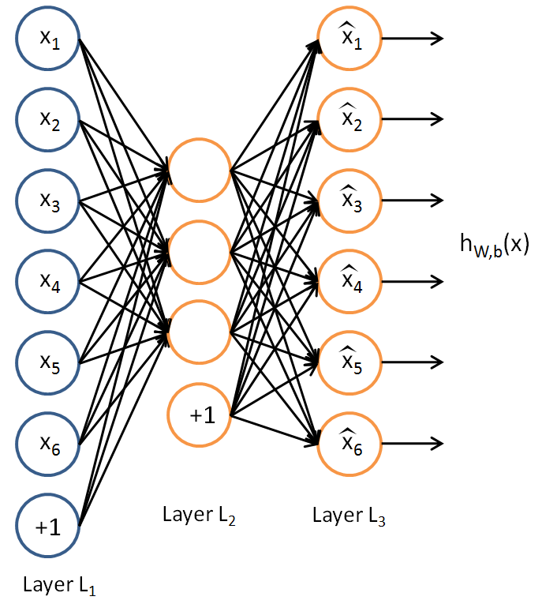

**Figure: An autoencoder with one hidden layer ($L_2$), courtesy by [Stanford UFLDL Tutorial: Autoencoders](http://ufldl.stanford.edu/tutorial/unsupervised/Autoencoders/)**

First, we define some parameters before building the deep neural network model.

- The `maxlen` should be equal or less than your input dimension. For example, we set up `200` since that most of the nursing notes have less than 200 words.
- The `encoding_dim` is the number of the output dimension. We choose `32` to get the 32-dimension vector for each document.
- Therefore, all documents will be truncated to 200 words (at most), and the 200-dimension vectors will be encoded into 32-dimension vectors.
- `batch_size` and `epochs` are training parameters, you may change them to get better results.

```r
library(keras)
maxlen <- 200
encoding_dim <- 32
batch_size <- 10
epochs <- 20
```

Next, we need to prepare the input data for deep neural network. Free text needs to be converted to index sequence for Keras input. `text_tokenizer` and `fit_text_tokenizer` functions help us tokenize our raw data, and `texts_to_sequences` function converts our textual data to a list of index sequences. Since lengths of nursing notes are all different, we use `pad_sequences` to pad the sequences (pad the sequences with 0 to the left), and let all notes (now index sequences) have all the same length. You may use `head(data_idx)` to see how the data looks like after transformation.

```r
tok <- text_tokenizer(2000, lower = TRUE, split = " ", char_level = FALSE)
fit_text_tokenizer(tok, data)
data_idx <- texts_to_sequences(tok, data)

data_idx <- data_idx %>%
  pad_sequences(maxlen = maxlen)

head(data_idx)
```

```
##      [,1] [,2] [,3] [,4] [,5] [,6] [,7] [,8] [,9] [,10] [,11] [,12] [,13]
## [1,]  363  191  376    8  507  436  478    3  509     5   595    29     9
## [2,]   37  138 1293    2  558    1   11  135  814     3  1513   151    21
## [3,]   31  319  275    1 1351  337  457  109   33  1883    57   940   702
## [4,]   44   14 1273    1   11   28   43  717    3  1765    20  1351   337
## [5,]  729  521   20  337    2    3  436  478    2   506   506     4    70
## [6,]   74  431  247  484  652    2 1837  484  652     8   223  1919     7
##      [,14] [,15] [,16] [,17] [,18] [,19] [,20] [,21] [,22] [,23] [,24]
## [1,]  1360  1048    94    29    55   376     5    36   362    19   117
## [2,]   100    33   441    32   348     8   119   101    51    62  1126
## [3,]   572   817   723    29     4   117    94   134  1072    44    14
## [4,]     1   940  1566     4    20     6    79   130     3   788    99
## [5,]    20   449     2   179    20   337  1194   609   337   153     4
## [6,]     2   103     5   374    97  1239   822   773   554    64   939
##      [,25] [,26] [,27] [,28] [,29] [,30] [,31] [,32] [,33] [,34] [,35]
```

[output cut: 118 more lines]

Then we split the data into training (70%) and validation sets (30%).

```r
inTraining <- 1:floor(nrow(data_idx) * 0.7)
x_train <- data_idx[inTraining, ]
x_test <- data_idx[-inTraining, ]
```

Now we can build a neural network structure with one hidden layer! We use `keras_model_sequential` function to initialize a new Keras model. You need to do it every time before constructing your new model.

In the R version of Keras, you can use `%>%` to stack the neural layer to your model. Imagine that your model is empty in the beginning, and you stack layer `e1`, then `d1` on it. Here the `e1` layer is the encoder, which inputs your list of index sequences, and output a hidden representation (with the dimension size you’ve assigned, here `32`). The `d1` layer is the decoder, which may take the hidden representation generated by the encoder, and try to reconstruct the original information (your input, with dimension size = `maxlen`).

The algorithm tries to minimize the difference (technically we call it ‘cost’) between your original input and the result of reconstruction. We use `adam` as an optimizer, and evaluate the cost by `binary_crossentropy` for this important step. There are also many different optimizers, such as `sgd`, `rmsprop`, `adadelta`, … that you can do experiments. Now the model is generated, and you can use `summary` function to see how it looks like.

```r
# initialize the model
model <- keras_model_sequential()

model %>%
  layer_dense(name = 'e1', units = encoding_dim, activation = 'relu', input_shape = maxlen) %>%
  layer_dense(name = 'd1', units = maxlen, activation = 'sigmoid')

model %>% compile(
  loss = "binary_crossentropy",
  optimizer = "adam"
)

summary(model)
```

```
## Model
## ___________________________________________________________________________
## Layer (type)                     Output Shape                  Param #
## ===========================================================================
## e1 (Dense)                       (None, 32)                    6432
## ___________________________________________________________________________
## d1 (Dense)                       (None, 200)                   6600
## ===========================================================================
## Total params: 13,032
## Trainable params: 13,032
## Non-trainable params: 0
## ___________________________________________________________________________
##
##
```

Then we use our data to fit the model, `x_train` as training data and `x_test` for validation. You may change `batch_size` and `epochs` to get better results. This model fitting step may take minutes to run.

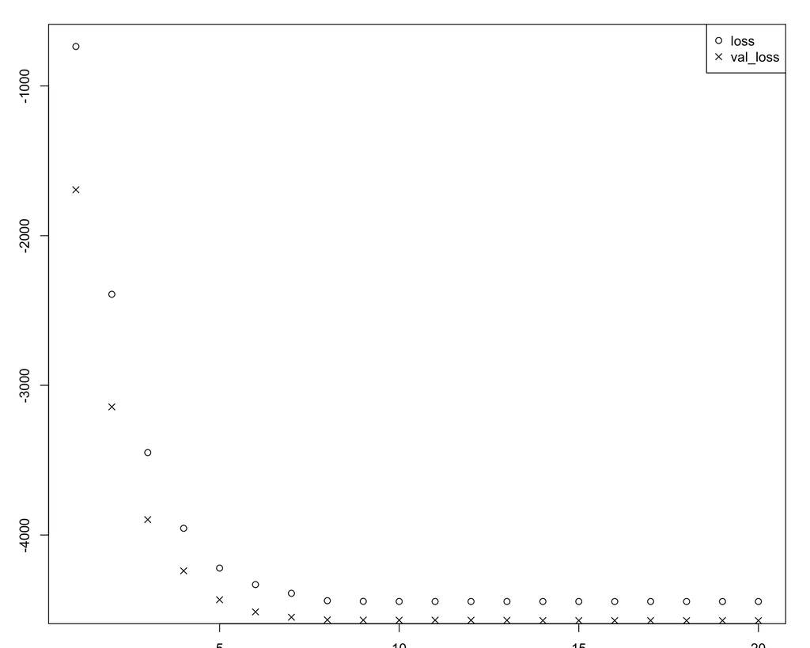

```r
history <- model %>% fit(
  x_train, x_train,
  batch_size = batch_size,
  epochs = epochs,
  shuffle = TRUE,
  validation_data = list(x_test, x_test)
)

plot(history)
```

Once the autoencoder is constructed and optimized by the data, we can now extract the hidden representation from the model. The hidden representation is the output of the encoder, which is the output of `e1` layer. We can use `keras_model` and `predict` functions to get the representation and save it in the variable `intermediate_output`.

```r
layer_name <- 'e1'

intermediate_layer_model <- keras_model(inputs = model$input,
                                        outputs = get_layer(model, layer_name)$output)
intermediate_output <- predict(intermediate_layer_model, x_train)
dim(intermediate_output)
```

```
## [1] 301  32
```

```r
head(intermediate_output)
```

```
##          [,1]     [,2]      [,3]      [,4]      [,5]     [,6]      [,7]
## [1,]   0.0000 1639.042  84.44209 666.24622  257.7635   0.0000 1751.1661
## [2,] 567.6916 1496.325 352.89493 157.61400  730.1945 139.9446  865.7642
## [3,]   0.0000 1815.915   0.00000  12.83695 2463.7791 699.8089 1910.0526
## [4,]   0.0000 1877.227   0.00000 980.13293  478.8404 293.3696 1624.8893
## [5,]   0.0000 1405.455   0.00000 939.84064  696.5231   0.0000  484.1179
## [6,]   0.0000 2968.973 195.93867   0.00000  153.0294 320.7863 1526.2048
##      [,8] [,9]    [,10]     [,11]     [,12]     [,13] [,14]    [,15]
## [1,]    0    0 206.0261 583.49518 1752.9551 1333.0161     0 2659.139
## [2,]    0    0   0.0000 698.31891 1026.8657 2163.3354     0 2034.580
## [3,]    0    0   0.0000  24.52592 1637.7726 1677.3268     0 1796.272
## [4,]    0    0   0.0000 957.86993 2229.7930  456.5674     0 3025.994
## [5,]    0    0   0.0000 329.07123  631.8087  929.4539     0 2257.687
## [6,]    0    0   0.0000 895.51227 1405.4783  645.5356     0 1630.735
##          [,16]     [,17]    [,18] [,19]    [,20] [,21] [,22]    [,23]
```

[output cut: 20 more lines]

We can visualize how the documents located in the vector space using principal component analysis (PCA) (using `princomp` function, `scores[, 1:2]` for first two principal components).

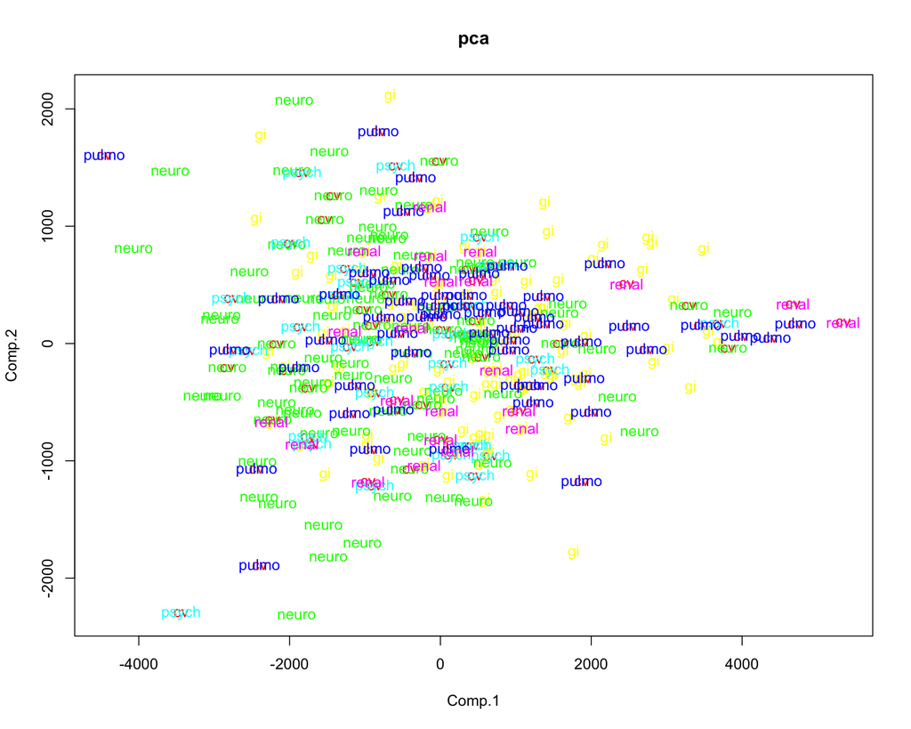

```r
colors <- rainbow(length(unique(as.factor(label))))

pca <- princomp(intermediate_output)$scores[, 1:2]
plot(pca, t='n', main="pca")
text(pca, labels=label, col=colors[label])
```

t-SNE is an awesome dimension reduction algorithm if you want to visualize how the hidden representation looks like in the vector space. The R implementation of t-SNE algorithm is in `Rtsne` package. Let’s see how it performs compared to PCA.

```r
library(Rtsne)

tsne <- Rtsne(as.matrix(intermediate_output), dims = 2, perplexity = 30,
              verbose = TRUE, max_iter = 500)
```

```
## Read the 301 x 32 data matrix successfully!
## Using no_dims = 2, perplexity = 30.000000, and theta = 0.500000
## Computing input similarities...
## Normalizing input...
## Building tree...
##  - point 0 of 301
## Done in 0.04 seconds (sparsity = 0.406684)!
## Learning embedding...
## Iteration 50: error is 60.325748 (50 iterations in 0.18 seconds)
## Iteration 100: error is 61.399892 (50 iterations in 0.17 seconds)
## Iteration 150: error is 60.608131 (50 iterations in 0.18 seconds)
## Iteration 200: error is 59.332856 (50 iterations in 0.16 seconds)
## Iteration 250: error is 58.758200 (50 iterations in 0.17 seconds)
## Iteration 300: error is 1.444816 (50 iterations in 0.14 seconds)
## Iteration 350: error is 1.164337 (50 iterations in 0.14 seconds)
## Iteration 400: error is 1.114216 (50 iterations in 0.12 seconds)
## Iteration 450: error is 1.113547 (50 iterations in 0.13 seconds)
## Iteration 500: error is 1.112694 (50 iterations in 0.12 seconds)
## Fitting performed in 1.50 seconds.
```

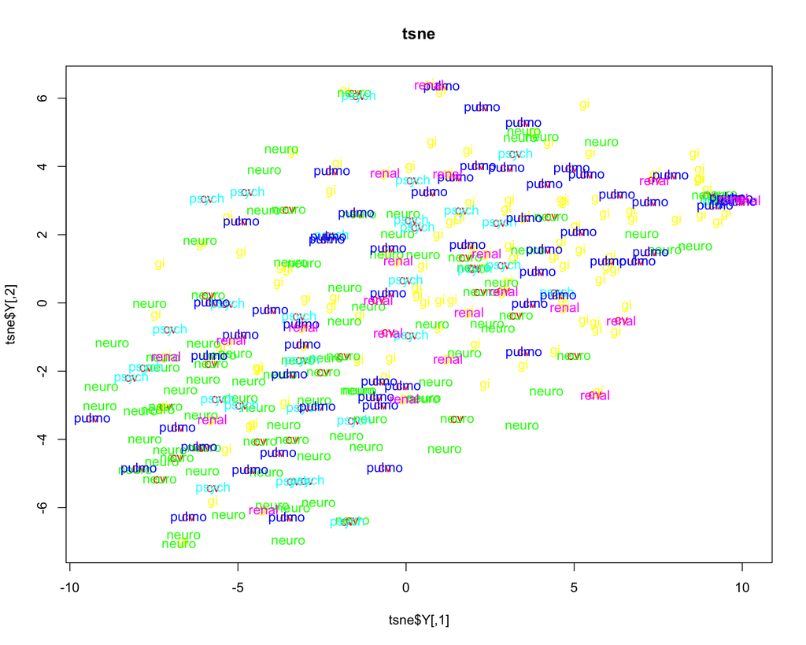

```r
plot(tsne$Y, t='n', main="tsne")
text(tsne$Y, labels=label, col=colors[label])
```

### Exercise

The autoencoder can be extended to not only single hidden layer. Let’s try to implement an autoencoder with 5 hidden layers instead of just one (encode/decode 3 times, respectively). The output of each layer can be a unique feature representation. However, in general, we usually pick up the middle-most layer with the smallest size of dimension as the representation we want (here the output of `e3` layer).

### Answer

```r
model <- keras_model_sequential()
model %>%
  layer_dense(name = 'e1', units = 128, activation = 'relu', input_shape = maxlen) %>%
  layer_dense(name = 'e2', units = 64, activation = 'relu') %>%
  layer_dense(name = 'e3', units = encoding_dim, activation = 'relu') %>%
  layer_dense(name = 'd1', units = 64, activation = 'relu') %>%
  layer_dense(name = 'd2', units = 128, activation = 'relu') %>%
  layer_dense(name = 'd3', units = maxlen, activation = 'sigmoid')

model %>% compile(
  loss = "binary_crossentropy",
  optimizer = "adadelta"
)

summary(model)
```

```
## Model
## ___________________________________________________________________________
## Layer (type)                     Output Shape                  Param #
## ===========================================================================
## e1 (Dense)                       (None, 128)                   25728
## ___________________________________________________________________________
## e2 (Dense)                       (None, 64)                    8256
## ___________________________________________________________________________
## e3 (Dense)                       (None, 32)                    2080
## ___________________________________________________________________________
## d1 (Dense)                       (None, 64)                    2112
## ___________________________________________________________________________
## d2 (Dense)                       (None, 128)                   8320
## ___________________________________________________________________________
## d3 (Dense)                       (None, 200)                   25800
## ===========================================================================
## Total params: 72,296
## Trainable params: 72,296
## Non-trainable params: 0
## ___________________________________________________________________________
##
##
```

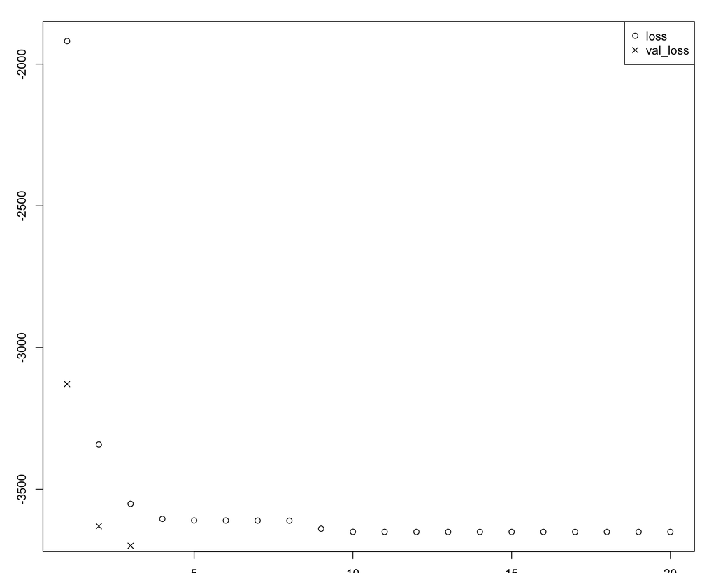

```r
history <- model %>% fit(
  x_train, x_train,
  batch_size = batch_size,
  epochs = epochs,
  shuffle = TRUE,
  validation_data = list(x_test, x_test)
)
plot(history)
```

```r
layer_name <- 'e3'
intermediate_layer_model <- keras_model(inputs = model$input,
                                        outputs = get_layer(model, layer_name)$output)
intermediate_output <- predict(intermediate_layer_model, x_train)

tsne <- Rtsne(as.matrix(intermediate_output), dims = 2, perplexity = 30,
              verbose = TRUE, max_iter = 500)
```

```
## Read the 301 x 32 data matrix successfully!
## Using no_dims = 2, perplexity = 30.000000, and theta = 0.500000
## Computing input similarities...
## Normalizing input...
## Building tree...
##  - point 0 of 301
## Done in 0.04 seconds (sparsity = 0.386927)!
## Learning embedding...
## Iteration 50: error is 56.005454 (50 iterations in 0.16 seconds)
## Iteration 100: error is 55.621230 (50 iterations in 0.15 seconds)
## Iteration 150: error is 54.998368 (50 iterations in 0.16 seconds)
## Iteration 200: error is 54.711908 (50 iterations in 0.17 seconds)
## Iteration 250: error is 54.685561 (50 iterations in 0.14 seconds)
## Iteration 300: error is 0.822132 (50 iterations in 0.13 seconds)
## Iteration 350: error is 0.787699 (50 iterations in 0.12 seconds)
## Iteration 400: error is 0.782643 (50 iterations in 0.12 seconds)
## Iteration 450: error is 0.767762 (50 iterations in 0.13 seconds)
## Iteration 500: error is 0.764190 (50 iterations in 0.12 seconds)
## Fitting performed in 1.41 seconds.
```

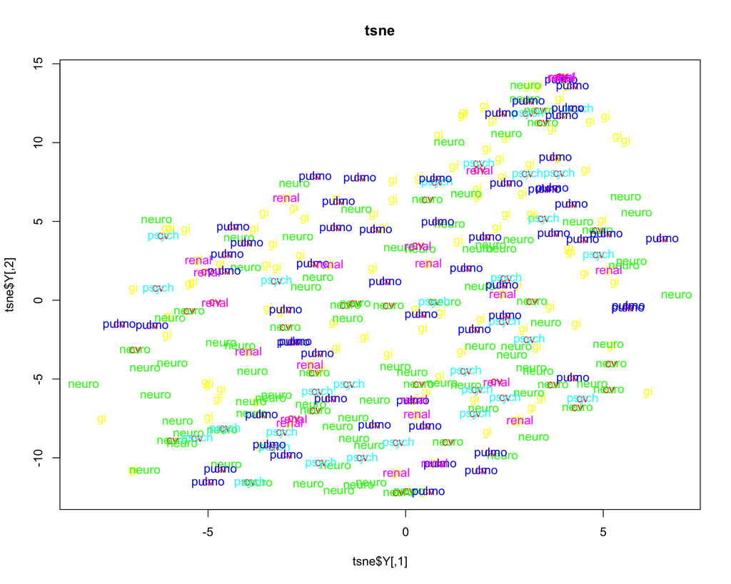

```r
plot(tsne$Y, t='n', main="tsne")
text(tsne$Y, labels=label, col=colors[label])
```

## Conclusion

Thank you for chekcing out the second workshop. We hope that you are much familiar with laguage modeling and deep learning using R.